# Homework 1

## Dataset for this homework

These homeworks are not graded, but are provided to give you extra practice.

Let’s explore the `airquality` example dataset that comes with R.

```r
data(airquality)
```

Remember that you can learn more about it by reading its help page:

```r
?airquality
```

## Exercises

1. Use some of the functions that you have learned for previewing the data frame. How many rows and columns does it have? What is the data type of each column? What is the name of each column?

```r
head(airquality)
```

```
##   Ozone Solar.R Wind Temp Month Day
## 1    41     190  7.4   67     5   1
## 2    36     118  8.0   72     5   2
## 3    12     149 12.6   74     5   3
## 4    18     313 11.5   62     5   4
## 5    NA      NA 14.3   56     5   5
## 6    28      NA 14.9   66     5   6
```

```r
str(airquality)
```

```
## 'data.frame':    153 obs. of  6 variables:
##  $ Ozone  : int  41 36 12 18 NA 28 23 19 8 NA ...
##  $ Solar.R: int  190 118 149 313 NA NA 299 99 19 194 ...
##  $ Wind   : num  7.4 8 12.6 11.5 14.3 14.9 8.6 13.8 20.1 8.6 ...
##  $ Temp   : int  67 72 74 62 56 66 65 59 61 69 ...
##  $ Month  : int  5 5 5 5 5 5 5 5 5 5 ...
##  $ Day    : int  1 2 3 4 5 6 7 8 9 10 ...
```

2. Sort the data frame by temperature, then by wind speed.

```r
# in the R base:
airquality[order(airquality$Temp, airquality$Wind),]
```

```
##     Ozone Solar.R Wind Temp Month Day
## 5      NA      NA 14.3   56     5   5
## 27     NA      NA  8.0   57     5  27
## 25     NA      66 16.6   57     5  25
## 18      6      78 18.4   57     5  18
## 15     18      65 13.2   58     5  15
## 26     NA     266 14.9   58     5  26
## 21      1       8  9.7   59     5  21
## 8      19      99 13.8   59     5   8
## 23      4      25  9.7   61     5  23
## 24     32      92 12.0   61     5  24
## 9       8      19 20.1   61     5   9
## 20     11      44  9.7   62     5  20
## 4      18     313 11.5   62     5   4
## 148    14      20 16.6   63     9  25
```

[output cut: 139 more lines]

```r
# in dplyr
library(dplyr)
airquality %>%
  arrange(Temp, Wind)
```

```
##     Ozone Solar.R Wind Temp Month Day
## 1      NA      NA 14.3   56     5   5
## 2      NA      NA  8.0   57     5  27
## 3      NA      66 16.6   57     5  25
## 4       6      78 18.4   57     5  18
## 5      18      65 13.2   58     5  15
## 6      NA     266 14.9   58     5  26
## 7       1       8  9.7   59     5  21
## 8      19      99 13.8   59     5   8
## 9       4      25  9.7   61     5  23
## 10     32      92 12.0   61     5  24
## 11      8      19 20.1   61     5   9
## 12     11      44  9.7   62     5  20
## 13     18     313 11.5   62     5   4
## 14     14      20 16.6   63     9  25
```

[output cut: 139 more lines]

```r
## Note that both of those commands display the sorted data, but don't change
## the original data frame.
```

3. Make a new data frame from the original, containing only the observations from August and September. Omit the Wind and Temp columns from this new data frame.

```r
# in the R base
# (Your code might look slightly different but accomplish the same thing.)
airquality_sub <- airquality[airquality$Month %in% c(8,9),
                             c("Ozone", "Solar.R", "Month", "Day")]

# in dplyr
airquality_sub <- airquality %>%
  filter(Month %in% c(8,9)) %>%
  select(Ozone, Solar.R, Month, Day)
```

4. Make a scatter plot of ozone vs. wind speed.

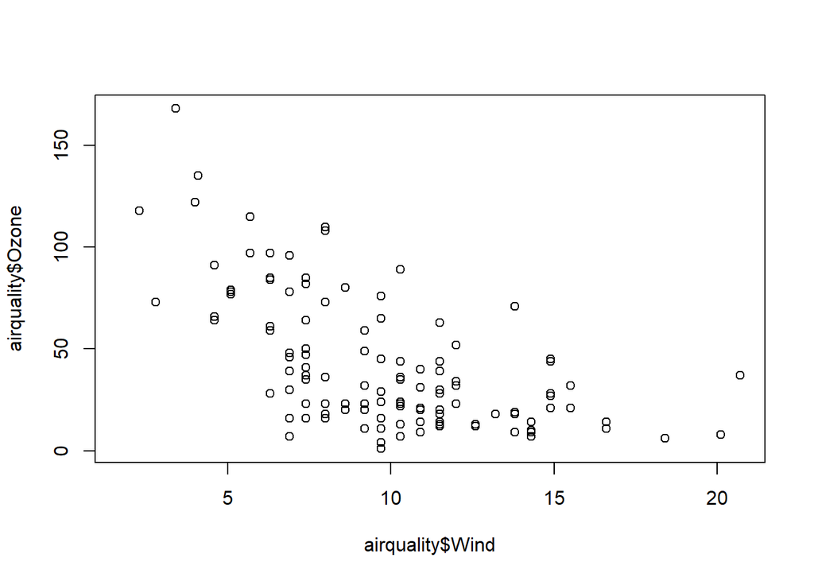

```r
# in the R base
plot(airquality$Wind, airquality$Ozone)
```

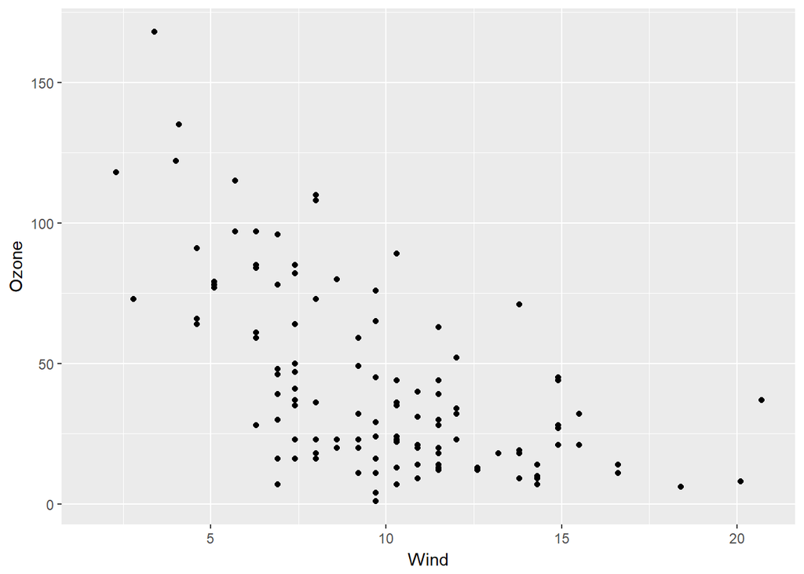

```r
# in ggplot2
library(ggplot2)
ggplot(airquality, aes(x = Wind, y = Ozone)) +
  geom_point()
```

5. Within each month, get the mean of the first four columns (Ozone, Solar.R, Wind, and Temp). Since there are some missing data, you should set the `na.rm` argument of `mean` to `TRUE`.

```r
# in the R base; there is one function called `by` that we haven't covered yet,
# that works like tapply but on data frames.
by(airquality[,1:4], airquality$Month, colMeans, na.rm = TRUE)
```

```
## airquality$Month: 5
##     Ozone   Solar.R      Wind      Temp
##  23.61538 181.29630  11.62258  65.54839
## --------------------------------------------------------
## airquality$Month: 6
##     Ozone   Solar.R      Wind      Temp
##  29.44444 190.16667  10.26667  79.10000
## --------------------------------------------------------
## airquality$Month: 7
##      Ozone    Solar.R       Wind       Temp
##  59.115385 216.483871   8.941935  83.903226
## --------------------------------------------------------
## airquality$Month: 8
##      Ozone    Solar.R       Wind       Temp
##  59.961538 171.857143   8.793548  83.967742
## --------------------------------------------------------
## airquality$Month: 9
##     Ozone   Solar.R      Wind      Temp
##  31.44828 167.43333  10.18000  76.90000
```

```r
# or we could use tapply on individual columns
tapply(airquality$Ozone, airquality$Month, mean, na.rm = TRUE)
```

```
##        5        6        7        8        9
## 23.61538 29.44444 59.11538 59.96154 31.44828
```

```r
tapply(airquality$Solar.R, airquality$Month, mean, na.rm = TRUE)
```

```
##        5        6        7        8        9
## 181.2963 190.1667 216.4839 171.8571 167.4333
```

```r
tapply(airquality$Wind, airquality$Month, mean, na.rm = TRUE)
```

```
##         5         6         7         8         9
## 11.622581 10.266667  8.941935  8.793548 10.180000
```

```r
tapply(airquality$Temp, airquality$Month, mean, na.rm = TRUE)
```

```
##        5        6        7        8        9
## 65.54839 79.10000 83.90323 83.96774 76.90000
```

```r
# in dplyr:
airquality %>%
  group_by(Month) %>%
  summarize(mean_ozone = mean(Ozone, na.rm = TRUE),
            mean_solar.r = mean(Solar.R, na.rm = TRUE),
            mean_wind = mean(Wind, na.rm = TRUE),
            mean_temp = mean(Temp, na.rm = TRUE))
```

```
## # A tibble: 5 x 5
##   Month mean_ozone mean_solar.r mean_wind mean_temp
##   <int>      <dbl>        <dbl>     <dbl>     <dbl>
## 1     5       23.6         181.     11.6       65.5
## 2     6       29.4         190.     10.3       79.1
## 3     7       59.1         216.      8.94      83.9
## 4     8       60.0         172.      8.79      84.0
## 5     9       31.4         167.     10.2       76.9
```

6. Extract a vector of ozone values, but only for days where the solar radiation was below 100 in the month of May.

```r
# Use `which` rather than direct Boolean indexing, because there are some
# missing data.
airquality$Ozone[which(airquality$Solar.R < 100 & airquality$Month == 5)]
```

```
##  [1] 19  8 18  6 11  1  4 32 NA 23
```

```r
# with dplyr:
filter(airquality, Solar.R < 100, Month == 5)$Ozone
```

```
##  [1] 19  8 18  6 11  1  4 32 NA 23
```

7. Say you want to take the mean of a vector called `myvect`, and you want to ignore `NA` (missing) values. Which of the following function calls will work? Which won’t? Why?

```r
mean(myvect, TRUE)             # 1
mean(myvect, na.rm = TRUE)     # 2
mean(na.rm = TRUE, x = myvect) # 3
mean(myvect, 0, TRUE)          # 4
mean(x = myvect, na.rm = TRUE) # 5
```

```r
# 1 won't work; `TRUE` gets passed to `trim`, the second argument.
# 2 will work; myvect gets passed to x as the first argument, and TRUE is
# passed to the correct named argument.
# 3 will work; both arguments are named, so the order doesn't matter.
# 4 will work; arguments are not named but are in the correct order.
# 5 will work, like # 3.
```

8. Say you want to sort `airquality` by Day, and so you write the following code:

```r
airquality %>%
  arrange(Day)
```

```
##     Ozone Solar.R Wind Temp Month Day
## 1      41     190  7.4   67     5   1
## 2      NA     286  8.6   78     6   1
## 3     135     269  4.1   84     7   1
## 4      39      83  6.9   81     8   1
## 5      96     167  6.9   91     9   1
## 6      36     118  8.0   72     5   2
## 7      NA     287  9.7   74     6   2
## 8      49     248  9.2   85     7   2
## 9       9      24 13.8   81     8   2
## 10     78     197  5.1   92     9   2
## 11     12     149 12.6   74     5   3
## 12     NA     242 16.1   67     6   3
## 13     32     236  9.2   81     7   3
## 14     16      77  7.4   82     8   3
```

[output cut: 139 more lines]

However, when you run

```r
head(airquality)
```

```
##   Ozone Solar.R Wind Temp Month Day
## 1    41     190  7.4   67     5   1
## 2    36     118  8.0   72     5   2
## 3    12     149 12.6   74     5   3
## 4    18     313 11.5   62     5   4
## 5    NA      NA 14.3   56     5   5
## 6    28      NA 14.9   66     5   6
```

you see that the data frame is still in the original order.

Rewrite the code to permanently sort the data frame for future use.

```r
airquality <- airquality %>%
  arrange(Day)
```